# Análisis de Violencia en Colombia

J. Sebastián M. Benítez

Andrés Paredes

April 17, 2019

## Limpieza del Dataset ProyeccionMunicipios2005_2020

Primero buscamos un dataset con la cantidad total proyectada de habitantes por municipio. La información de este dataset será usada para calcular nuestro índice de violencia.

El dataset se puede encontrar en la siguiente ruta: https://www.dane.gov.co/files/investigaciones/poblacion/proyepobla06_20/ProyeccionMunicipios2005_2020.xls

Los datos se ven así:

| COLOMBIA. PROYECCIONES DE POBLACIÓN MUNICIPALES POR ÁREA | ..2 | ..3 | ..4 | ..5 | ..6 | ..7 | ..8 |
| --- | --- | --- | --- | --- | --- | --- | --- |
| 2005 - 2020 | NA | NA | NA | NA | NA | NA | NA |
| A junio 30 | NA | NA | NA | NA | NA | NA | NA |
| NA | NA | NA | NA | TOTAL | NA | NA | NA |
| DP | DPNOM | DPMP | MPIO | 2005 | 2006 | 2007 | 2008 |
| 05 | Antioquia | 05001 | Medellín | 2214494 | 2239003 | 2265244 | 2291378 |
| 05 | Antioquia | 05002 | Abejorral | 20249 | 20113 | 20022 | 19930 |
| 05 | Antioquia | 05004 | Abriaquí | 2690 | 2636 | 2570 | 2504 |
| 05 | Antioquia | 05021 | Alejandría | 3816 | 3789 | 3747 | 3724 |
| 05 | Antioquia | 05030 | Amagá | 27155 | 27455 | 27709 | 27950 |
| 05 | Antioquia | 05031 | Amalfi | 20525 | 20665 | 20826 | 20985 |

Eliminamos la información irrelevante del header y ajustamos el nombre de las columnas

| DP | DPNOM | DPMP | MPIO | 2005 | 2006 | 2007 | 2008 | 2009 | 2010 | 2011 | 2012 |
| --- | --- | --- | --- | --- | --- | --- | --- | --- | --- | --- | --- |
| 05 | Antioquia | 05001 | Medellín | 2214494 | 2239003 | 2265244 | 2291378 | 2317336 | 2343049 | 2368282 | 2393011 |
| 05 | Antioquia | 05002 | Abejorral | 20249 | 20113 | 20022 | 19930 | 19853 | 19750 | 19672 | 19570 |
| 05 | Antioquia | 05004 | Abriaquí | 2690 | 2636 | 2570 | 2504 | 2458 | 2397 | 2336 | 2290 |
| 05 | Antioquia | 05021 | Alejandría | 3816 | 3789 | 3747 | 3724 | 3688 | 3652 | 3618 | 3575 |
| 05 | Antioquia | 05030 | Amagá | 27155 | 27455 | 27709 | 27950 | 28192 | 28433 | 28664 | 28897 |
| 05 | Antioquia | 05031 | Amalfi | 20525 | 20665 | 20826 | 20985 | 21138 | 21295 | 21449 | 21615 |

Eliminamos las columnas que no necesitamos. En este caso usaremos solo el año 2017 debido a que la información del dataset de hurtos solo está disponible para el 2017.

| DPNOM | MPIO | 2017 |
| --- | --- | --- |
| Antioquia | Medellín | 2508452 |
| Antioquia | Abejorral | 19096 |
| Antioquia | Abriaquí | 2019 |
| Antioquia | Alejandría | 3393 |
| Antioquia | Amagá | 29980 |
| Antioquia | Amalfi | 22414 |

Los últimos datos del dataset se ven así:

| DPNOM | MPIO | 2017 |
| --- | --- | --- |
| Vichada | Santa Rosalía | 4138 |
| Vichada | Cumaribo | 38634 |
| NA | Total Nacional | 49291925 |
| NA | NA | NA |
| NA | NA | NA |
| NA | NA | NA |
| NA | NA | NA |
| Guachené, segregado de Caloto (Cauca), mediante Decreto 0653 de Diciembre 19 de 2006 | NA | NA |
| Norosí, segregado de Rioviejo (Bolívar), mediante Decreto 699 de Diciembre 20 de 2007 | NA | NA |
| Tuchín, segregado de San Andrés de Sotavento, mediante Ordenanza 09 de Diciembre 10 de 2007 y modificación de límites según Fallo del Tribunal Administrativo de Córdoba, Sala Tercera de Decisión, Mont… | NA | NA |
| San José de Uré, segregado de Montelíbano (Córdoba), mediante Ordenanza 11 de Diciembre 21 de 2007 | NA | NA |
| NA | NA | NA |
| NA | NA | NA |
| NA | NA | NA |
| NA | NA | NA |

Eliminamos las filas innecesarias

| DPNOM | MPIO | 2017 |
| --- | --- | --- |
| Vaupés | Papunaua (CD) | 837 |
| Vaupés | Yavaraté (CD) | 1231 |
| Vichada | Puerto Carreño | 16249 |
| Vichada | La Primavera | 16447 |
| Vichada | Santa Rosalía | 4138 |
| Vichada | Cumaribo | 38634 |

- Eliminamos las tildes para estandarizar los nombres y no tener problemas de merge después.
- Eliminamos los espacios y la puntuación.
- Convertimos todo a mayúsculas.
- Convertimos BOGOTADC a CUNDINAMARCA puesto que el DANE toma a Bogotá como un departamento diferente y para el merge con otros datasets deben ser el mismo.
- Eliminamos abreviaturas dentro de paréntesis que salen al lado de los nombres. Ejemplo: (CD).

| DPNOM | MPIO | 2017 |
| --- | --- | --- |
| VAUPES | PAPUNAUA | 837 |
| VAUPES | YAVARATE | 1231 |
| VICHADA | PUERTOCARRENO | 16249 |
| VICHADA | LAPRIMAVERA | 16447 |
| VICHADA | SANTAROSALIA | 4138 |
| VICHADA | CUMARIBO | 38634 |

## Limpieza del Dataset HurtoANSI

Obtenemos un dataset con la información de hurtos del año 2017 en Colombia.

El dataset se puede encontrar en la siguiente ruta: https://www.datos.gov.co/Seguridad-y-Defensa/Hurto-a-personas-2017/cwdd-8tiq

Los datos se ven así:

| Fecha | Departamento | Municipio | Día | Hora | Barrio | Zona | Clase.de.sitio | Arma.empleada | Móvil.Agresor |
| --- | --- | --- | --- | --- | --- | --- | --- | --- | --- |
| 01/01/2017 12:00:00 AM | ANTIOQUIA | MEDELLÍN (CT) | Domingo | 12/31/1899 10:00:00 AM | LA CANDELARIA C-10 | URBANA | VIAS PUBLICAS | ARMA BLANCA / CORTOPUNZANTE | A PIE |
| 01/01/2017 12:00:00 AM | ANTIOQUIA | MEDELLÍN (CT) | Domingo | 12/31/1899 10:00:00 AM | LA CANDELARIA C-10 | URBANA | VIAS PUBLICAS | ARMA BLANCA / CORTOPUNZANTE | A PIE |
| 01/01/2017 12:00:00 AM | ANTIOQUIA | MEDELLÍN (CT) | Domingo | 12/31/1899 03:00:00 PM | LA CANDELARIA C-10 | URBANA | VIAS PUBLICAS | ARMA BLANCA / CORTOPUNZANTE | A PIE |

Eliminamos los puntos y las tildes de los nombres de las columnas para que sea más fácil trabajar con ellas

| Fecha | Departamento | Municipio | Dia | Hora | Barrio | Zona | Clasedesitio | Armaempleada | MovilAgresor |
| --- | --- | --- | --- | --- | --- | --- | --- | --- | --- |
| 01/01/2017 12:00:00 AM | ANTIOQUIA | MEDELLÍN (CT) | Domingo | 12/31/1899 10:00:00 AM | LA CANDELARIA C-10 | URBANA | VIAS PUBLICAS | ARMA BLANCA / CORTOPUNZANTE | A PIE |
| 01/01/2017 12:00:00 AM | ANTIOQUIA | MEDELLÍN (CT) | Domingo | 12/31/1899 10:00:00 AM | LA CANDELARIA C-10 | URBANA | VIAS PUBLICAS | ARMA BLANCA / CORTOPUNZANTE | A PIE |
| 01/01/2017 12:00:00 AM | ANTIOQUIA | MEDELLÍN (CT) | Domingo | 12/31/1899 03:00:00 PM | LA CANDELARIA C-10 | URBANA | VIAS PUBLICAS | ARMA BLANCA / CORTOPUNZANTE | A PIE |

- Eliminamos abreviaturas dentro de paréntesis que salen al lado de los nombres. Ejemplo: (CT).
- Unificamos nombres de municipios y departamentos que están diferentes entre los datasets.
- Eliminamos las tildes.
- Eliminamos espacios y signos de puntuación.

| Fecha | Departamento | Municipio | Dia | Hora | Barrio | Zona | Clasedesitio | Armaempleada | MovilAgresor |
| --- | --- | --- | --- | --- | --- | --- | --- | --- | --- |
| 01/01/2017 12:00:00 AM | ANTIOQUIA | MEDELLIN | Domingo | 12/31/1899 10:00:00 AM | LA CANDELARIA C-10 | URBANA | VIAS PUBLICAS | ARMA BLANCA / CORTOPUNZANTE | A PIE |
| 01/01/2017 12:00:00 AM | ANTIOQUIA | MEDELLIN | Domingo | 12/31/1899 10:00:00 AM | LA CANDELARIA C-10 | URBANA | VIAS PUBLICAS | ARMA BLANCA / CORTOPUNZANTE | A PIE |
| 01/01/2017 12:00:00 AM | ANTIOQUIA | MEDELLIN | Domingo | 12/31/1899 03:00:00 PM | LA CANDELARIA C-10 | URBANA | VIAS PUBLICAS | ARMA BLANCA / CORTOPUNZANTE | A PIE |

## Construcción de la tabla de datos generales

Obtenemos 3 datasets de la Encuesta de Convivencia y Seguridad Ciudadana realizada entre 2016 y 2017. Estos son:

- Datos de la vivienda
- Percepción de seguridad en el hogar
- Características generales de las personas

Hay que tener en cuenta que uno de los 3 datasets estÃ¡ separado por tabulación en vez de espacio.

Después los unimos para que sean un solo dataset.

| DIRECTORIO | SECUENCIA_ENCUESTA | SECUENCIA_P | ORDEN | FEX_C | P220 | P5785 | P5501 | P6210 | P6210S1 |
| --- | --- | --- | --- | --- | --- | --- | --- | --- | --- |
| 100000 | 1 | 1 | 1 | 63.58510 | 1 | 28 | 1 | 6 | 603 |
| 100002 | 1 | 1 | 1 | 58.90120 | 1 | 39 | 1 | 6 | 602 |
| 100004 | 1 | 1 | 1 | 66.79044 | 1 | 31 | 1 | 5 | 511 |
| 100006 | 1 | 1 | 1 | 61.28149 | 1 | 38 | 1 | 5 | 511 |
| 100008 | 1 | 1 | 1 | 56.96254 | 2 | 35 | 1 | 5 | 511 |
| 100010 | 1 | 1 | 1 | 54.59931 | 1 | 48 | 1 | 3 | 305 |

## Formato de variables no coincide con el tipo de variable

En el Dataset 1 convertimos los departamentos y municipios en tipo factor

|  | x |
| --- | --- |
| DPNOM | factor |
| MPIO | factor |
| 2017 | numeric |

En el Dataset 2:

- Convertimos la fecha de Factor a Date
- Convertimos el departamento y el municipio de Character a Factor
- Convertimos el Código Dane de Numeric a Factor
- Convertimos la hora de formato “DD/MM/RRRR HH:mm:ss AM” a formato “HH:mm:ss AM”

|  | x |
| --- | --- |
| Fecha | Date |
| Departamento | factor |
| Municipio | factor |
| Dia | factor |
| Hora | factor |
| Barrio | factor |
| Zona | factor |
| Clasedesitio | factor |
| Armaempleada | factor |
| MovilAgresor | factor |
| MovilVictima | factor |
| Edad | integer |
| Sexo | factor |
| Estadocivil | factor |
| Paisdenacimiento | factor |
| Clasedeempleado | factor |
| Profesion | factor |
| Escolaridad | factor |
| CodigoDANE | factor |
| Cantidad | integer |

En el Dataset 3:

|  | x |
| --- | --- |
| DIRECTORIO | integer |
| SECUENCIA_ENCUESTA | integer |
| SECUENCIA_P | integer |
| ORDEN | integer |
| FEX_C | numeric |
| P220 | integer |
| P5785 | integer |
| P5501 | integer |
| P6210 | integer |
| P6210S1 | integer |
| P1366 | integer |
| P1402 | integer |
| P1403 | integer |
| P1365 | integer |
| P1364 | integer |
| P1363 | integer |
| DEPMUNI | integer |
| P5747 | integer |
| P5752 | integer |
| P5752S1 | integer |
| P5090 | integer |
| P1398S1 | integer |
| P1398S2 | integer |
| P1398S3 | integer |
| P1398S4 | integer |
| P1398S5 | integer |
| P1398S6 | integer |
| P1398S7 | integer |
| P1398S8 | integer |
| P1398S9 | integer |
| P1398S10 | integer |
| P1398S11 | integer |
| P1590S1 | integer |
| P1590S2 | integer |
| P1590S3 | integer |
| P1590S4 | integer |
| P1590S5 | integer |
| P520S1 | integer |
| P520S2 | integer |
| P520S3 | integer |
| P520S4 | integer |
| P520S5 | integer |
| P520S6 | integer |
| P520S7 | integer |

## Observaciones duplicadas

Evaluando duplicados en el Dataset 1 pudimos observar que existen varios municipios con el mismo nombre en diferentes departamentos. Pero en general no hay duplicados de la combinación entre departamento y municipio.

| DPNOM | MPIO | 2017 |
| --- | --- | --- |
| LAGUAJIRA | ALBANIA | 27589 |
| SANTANDER | ALBANIA | 5230 |
| CAUCA | ARGELIA | 27221 |
| VALLEDELCAUCA | ARGELIA | 6389 |

Evaluando el Dataset 2 con todas las columnas, no pudimos observar existencia de duplicados.

## Valores perdidos

Evaluando el Dataset 1, no pudimos observar existencia de valores perdidos.

Evaluando el Dataset 2, podemos observar que hay 2195 valores perdidos.

| Var1 | Freq |
| --- | --- |
| FALSE | 3699905 |
| TRUE | 2195 |

|  | x |
| --- | --- |
| - | 1982 |
| CASADO | 37638 |
| DIVORCIADO | 3045 |
| SEPARADO | 2608 |
| SOLTERO | 97221 |
| UNION LIBRE | 40600 |
| VIUDO | 2011 |

|  | x |
| --- | --- |
| COLOMBIA | 179477 |
| - | 3578 |
| VENEZUELA | 432 |
| ESTADOS UNIDOS | 236 |
| ECUADOR | 117 |
| FRANCIA | 106 |
| (Other) | 1159 |

|  | x |
| --- | --- |
| - | 135713 |
| NO REPORTADA | 7601 |
| ADMINISTRACION DE EMPRESAS | 5502 |
| DERECHO | 2866 |
| INGENIERO | 2472 |
| LICENCIADO | 2217 |
| (Other) | 28734 |

|  | x |
| --- | --- |
| SECUNDARIA | 86340 |
| SUPERIOR | 47943 |
| PRIMARIA | 26643 |
| TECNICO | 14551 |
| TECNOLOGO | 5955 |
| - | 2093 |
| (Other) | 1580 |

## Análisis Univariado

Esto es para tener información general que pueda dar contexto a otras variables en el futuro

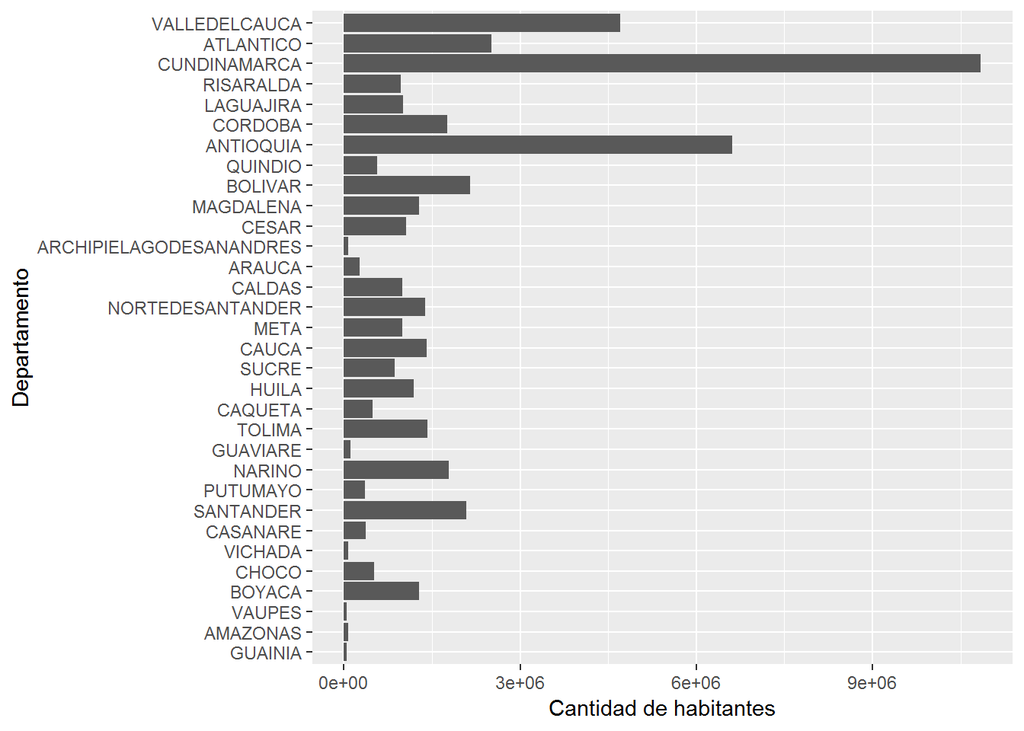

Observamos el resumen de las variables para crear ideas para los gráficos. También se verifican para revisar posibles valores extremos, perdidos o inconsistentes.

|  | Departamento | Municipio | Dia | Hora | Barrio | Zona |
| --- | --- | --- | --- | --- | --- | --- |
|  | CUNDINAMARCA :70804 | BOGOTADC :65482 | Domingo :20127 | 12:00:00 AM: 15351 | CENTRO : 7791 | OTRAS : 24 |
|  | ANTIOQUIA :25943 | MEDELLIN :17552 | Jueves :28045 | 10:00:00 AM: 4758 | LA CANDELARIA C-10 : 2749 | RURAL : 9594 |
|  | VALLEDELCAUCA:19720 | CALI :14708 | Lunes :23797 | 07:00:00 PM: 4232 | BELLA SUIZA E-1 : 2445 | URBANA:175487 |
|  | SANTANDER : 8276 | BARRANQUILLA: 5753 | Martes :27464 | 11:00:00 AM: 4055 | CHAPINERO CENTRAL E-2: 1145 | NA |
|  | ATLANTICO : 7449 | PASTO : 4487 | Miércoles:27878 | 08:00:00 PM: 3931 | EL POBLADO C-14 : 894 | NA |
|  | NARINO : 5663 | BUCARAMANGA : 4072 | Sábado :28451 | 03:00:00 PM: 3751 | EL CENTRO : 799 | NA |
|  | (Other) :47250 | (Other) :73051 | Viernes :29343 | (Other) :149027 | (Other) :169282 | NA |

|  | Clasedesitio | Armaempleada | MovilAgresor | MovilVictima | Edad | Sexo | Estadocivil |
| --- | --- | --- | --- | --- | --- | --- | --- |
|  | VIAS PUBLICAS :111142 | SIN EMPLEO DE ARMAS :89281 | A PIE :132694 | A PIE :143547 | Min. : 0.00 | - : 1 | - : 1982 |
|  | CASAS DE HABITACION : 5551 | ARMA BLANCA / CORTOPUNZANTE:43822 | PASAJERO MOTOCICLETA : 20354 | CONDUCTOR VEHICULO : 12323 | 1st Qu.: 25.00 | FEMENINO : 78476 | CASADO :37638 |
|  | FRENTE A RESIDENCIAS - VIA PUBLICA: 3072 | ARMA DE FUEGO :35800 | CONDUCTOR MOTOCICLETA: 13168 | PASAJERO BUS : 10211 | Median : 33.00 | MASCULINO:106628 | DIVORCIADO : 3045 |
|  | CARRETERA : 2600 | CONTUNDENTES :13959 | PASAJERO BUS : 7588 | CONDUCTOR MOTOCICLETA: 6423 | Mean : 35.17 | NA | SEPARADO : 2608 |
|  | LOCAL COMERCIAL : 2530 | ESCOPOLAMINA : 1893 | BICICLETA : 4581 | BICICLETA : 4299 | 3rd Qu.: 43.00 | NA | SOLTERO :97221 |
|  | CALLEJÓN : 2436 | NO REPORTADO : 164 | CONDUCTOR VEHICULO : 1802 | PASAJERO VEHICULO : 2009 | Max. :450.00 | NA | UNION LIBRE:40600 |
|  | (Other) : 57774 | (Other) : 186 | (Other) : 4918 | (Other) : 6293 | NA’s :2195 | NA | VIUDO : 2011 |

|  | Paisdenacimiento | Clasedeempleado | Profesion | Escolaridad | CodigoDANE |
| --- | --- | --- | --- | --- | --- |
|  | COLOMBIA :179477 | EMPLEADO PARTICULAR:105541 | - :135713 | SECUNDARIA:86340 | 11001000:65482 |
|  | - : 3578 | INDEPENDIENTE : 31893 | NO REPORTADA : 7601 | SUPERIOR :47943 | 5001000 :17552 |
|  | VENEZUELA : 432 | ESTUDIANTE : 14325 | ADMINISTRACION DE EMPRESAS: 5502 | PRIMARIA :26643 | 76001000:14708 |
|  | ESTADOS UNIDOS: 236 | AMA DE CASA : 6866 | DERECHO : 2866 | TECNICO :14551 | 8001000 : 5753 |
|  | ECUADOR : 117 | COMERCIANTE : 6755 | INGENIERO : 2472 | TECNOLOGO : 5955 | 52001000: 4487 |
|  | FRANCIA : 106 | EMPLEADO PUBLICO : 3651 | LICENCIADO : 2217 | - : 2093 | 68001000: 4072 |
|  | (Other) : 1159 | (Other) : 16074 | (Other) : 28734 | (Other) : 1580 | (Other) :73051 |

La siguiente gráfica muestra la cantidad de hurtos por Departamento. Podemos observar que hay más hurtos en Cundinamarca, Antioquia y Valle, pero esto es debido a que tienen más habitantes como se puede ver en la gráfica anterior.

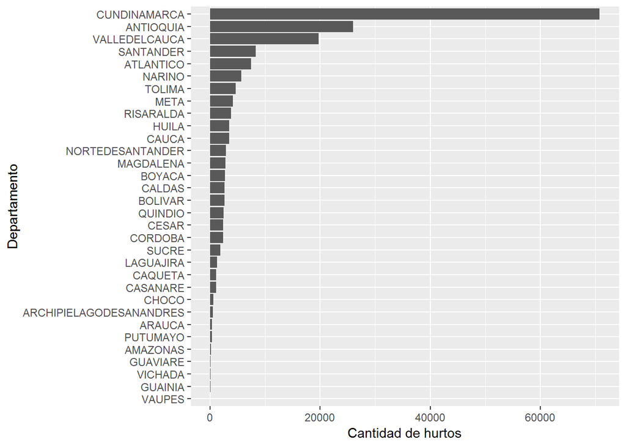

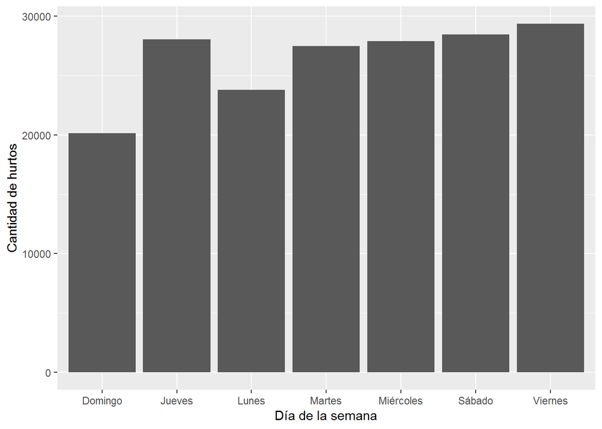

La siguiente tabla muestra que, según los datos, la hora más peligrosa es la media noche

|  | x |
| --- | --- |
| 12:00:00 AM | 15351 |
| 10:00:00 AM | 4758 |
| 07:00:00 PM | 4232 |
| 11:00:00 AM | 4055 |
| (Other) | 156709 |

La siguiente gráfica muestra que, a diferencia de lo que esperábamos, la mayor cantidad de hurtos son sin armas

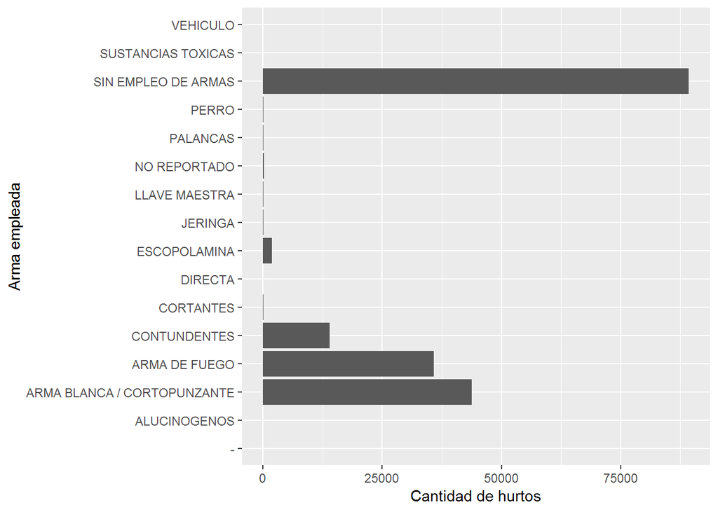

Las gráficas siguientes nos muestran que la mayor cantidad de hurtos son entre transeuntes

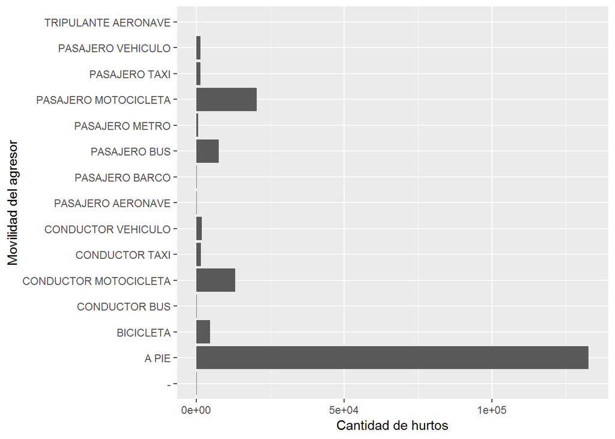

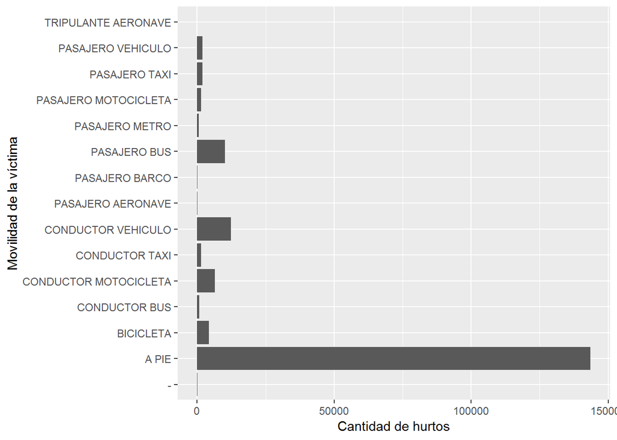

Bibliografía Proyecccion población Dane https://www.dane.gov.co/files/investigaciones/poblacion/proyepobla06_20/ProyeccionMunicipios2005_2020.xls Encuesta violencia en colombia http://microdatos.dane.gov.co/index.php/catalog/451/datafile/F1